# Spatial modeling of incidence and mortality childhood leukemia based on Colombian armed conflict and poverty for children born during the years 2002-2013

Pilar Montilla, Martha Bohorquez and Rafael Rentería

2021-08-05

**Packages**

```r
rm(list=ls())
require(rgdal)
require(pscl)
require(sf)
require(spdep)
require(spatialreg) #test.W, scores.listw
require(stringr)
require(performance)
require(AER)
require(ggplot2)
require(vcdExtra)
```

**Reading the shapefile of 1124 Colombian municipalities, defining the Coordinate Reference System and centroid and building some variables**

```r
#Reading the shapefile of 1124 Colombian municipalities
muncol <- rgdal::readOGR(dsn="muncol.shp")
muncol=spTransform(muncol,CRS("+init=epsg:21897"))
(l <- length(muncol))
```

```
## [1] 1124
```

```r
#Representative coordinate (centroid)
options(warn = -1)
xy0=data.frame(x=muncol$x,y=muncol$y)
coordinates(xy0) <- c('x','y')
proj4string(xy0) <- CRS("+init=epsg:4326")
xy0=spTransform(xy0,CRS("+init=epsg:21897"))

###Loops for avoiding NA
r <- sum(muncol$Ndeaths)/sum(muncol$NPop)
for (i in 1:l){
   if(muncol$NPop[i]==0){
      muncol$EsperadosDeNCancer[i] <- 1
   }
   else{
      muncol$EsperadosDeNCancer[i] <- muncol$NPop[i]*r
   }
}

muncol$IICA_Cat=muncol$IICA_Ca
muncol$IICA_Cat=str_replace_all(muncol$IICA_Cat,"Bajo", "Low")
muncol$IICA_Cat=str_replace_all(muncol$IICA_Cat,"Medio", "Medium")
muncol$IICA_CatLow=ifelse(muncol$IICA_Cat=="Low",1,0)
muncol$IICA_CatMed=ifelse(muncol$IICA_Cat=="Medium",1,0)
muncol$IICA_High=as.character(1-(muncol$IICA_CatLow+muncol$IICA_CatMed))
muncol$UBN=muncol$NBI
```

**Modeling leukemia Mortality Rate (LR) in terms of Colombian armed conflict index, poverty, rurality and health coverage. First, the usual Poisson regression model with mortality rate as response variable is estimated.**

```r
glmbaseLMR<-glm(Ndeaths ~IICA_High+UBN+Per_Rur+Cobertura+offset(log(EsperadosDeNCancer)), family = poisson,data = muncol)
anova(glmbaseLMR)
```

```
## Analysis of Deviance Table
##
## Model: poisson, link: log
##
## Response: Ndeaths
##
## Terms added sequentially (first to last)
##
##
##           Df Deviance Resid. Df Resid. Dev
## NULL                       1123     799.92
## IICA_High  1    0.694      1122     799.22
## UBN        1   43.405      1121     755.82
## Per_Rur    1    4.017      1120     751.80
## Cobertura  1    9.185      1119     742.62
```

```r
muncol$residLMR=residuals(glmbaseLMR)
summary(glmbaseLMR)
```

```
##
## Call:
## glm(formula = Ndeaths ~ IICA_High + UBN + Per_Rur + Cobertura +
##     offset(log(EsperadosDeNCancer)), family = poisson, data = muncol)
##
## Deviance Residuals:
##     Min       1Q   Median       3Q      Max
## -2.9317  -0.5949  -0.4108  -0.2389   3.3300
##
## Coefficients:
##              Estimate Std. Error z value Pr(>|z|)
## (Intercept) -0.583783   0.307508  -1.898  0.05764 .
## IICA_High1   0.107822   0.084777   1.272  0.20343
## UBN         -0.007902   0.003003  -2.632  0.00850 **
## Per_Rur     -0.002705   0.002370  -1.141  0.25380
## Cobertura    0.991687   0.336039   2.951  0.00317 **
## ---
## Signif. codes:  0 '***' 0.001 '**' 0.01 '*' 0.05 '.' 0.1 ' ' 1
##
## (Dispersion parameter for poisson family taken to be 1)
##
##     Null deviance: 799.92  on 1123  degrees of freedom
## Residual deviance: 742.62  on 1119  degrees of freedom
## AIC: 1271.7
##
## Number of Fisher Scoring iterations: 6
```

*Rurality and conflict armed index are not statistically significant in this first auxiliar model. However, we maintain these variables in the rest of the analysis and review its significance in the final model.*

*Checking excess zeros by comparison between the number of zeros predicted by the model with the observed number of zeros. Also checking overdispersion.*

```r
mu_LMR <- predict(glmbaseLMR, type = "response")  # predict expected mean count
expLMR <- sum(dpois(x = 0, lambda = mu_LMR))      # sum the probabilities of a zero count for each mean
round(expLMR)                                    #predicted number of zeros
```

```
## [1] 898
```

```r
sum(muncol$Ndeaths < 1)                          #observed number of zeros
```

```
## [1] 907
```

```r
zero.test(muncol$Ndeaths)                        #score test (van den Broek, 1995)
```

```
## Score test for zero inflation
##
##      Chi-square = 902.95398
##      df = 1
##      pvalue: < 2.22e-16
```

*Now, to validate the independence assumption, first, it is necessary to define spatial weighting possible matrices.*

```r
rook_nb_b=nb2listw(poly2nb(muncol,queen=FALSE), style="B",zero.policy = TRUE)
rook_nb_w=nb2listw(poly2nb(muncol,queen=FALSE), style="W",zero.policy = TRUE)

queen_nb_b=nb2listw(poly2nb(muncol,queen=TRUE), style="B",zero.policy = TRUE)
queen_nb_w=nb2listw(poly2nb(muncol,queen=TRUE), style="W",zero.policy = TRUE)

#Graphs neighbours
trinb=tri2nb(xy0)
options(warn = -1)
tri_nb_b=nb2listw(tri2nb(xy0), style="B",zero.policy = TRUE)
tri_nb_w=nb2listw(tri2nb(xy0), style="W",zero.policy = TRUE)

soi_nb_b=nb2listw(graph2nb(soi.graph(trinb,xy0)), style="B",zero.policy = TRUE)
soi_nb_w=nb2listw(graph2nb(soi.graph(trinb,xy0)), style="W",zero.policy = TRUE)

relative_nb_b=nb2listw(graph2nb(relativeneigh(xy0), sym=TRUE), style="B",zero.policy = TRUE)
relative_nb_w=nb2listw(graph2nb(relativeneigh(xy0), sym=TRUE), style="W",zero.policy = TRUE)

gabriel_nb_b=nb2listw(graph2nb(gabrielneigh(xy0), sym=TRUE), style="B",zero.policy = TRUE)
gabriel_nb_w=nb2listw(graph2nb(gabrielneigh(xy0), sym=TRUE), style="W",zero.policy = TRUE)

#Distance neighbours

knn1_nb_b=nb2listw(knn2nb(knearneigh(xy0, k = 1)), style="B",zero.policy = TRUE)
knn1_nb_w=nb2listw(knn2nb(knearneigh(xy0, k = 1)), style="W",zero.policy = TRUE)
knn2_nb_b=nb2listw(knn2nb(knearneigh(xy0, k = 2)), style="B",zero.policy = TRUE)
knn2_nb_w=nb2listw(knn2nb(knearneigh(xy0, k = 2)), style="W",zero.policy = TRUE)
knn3_nb_b=nb2listw(knn2nb(knearneigh(xy0, k = 3)), style="B",zero.policy = TRUE)
knn3_nb_w=nb2listw(knn2nb(knearneigh(xy0, k = 3)), style="W",zero.policy = TRUE)
knn4_nb_b=nb2listw(knn2nb(knearneigh(xy0, k = 4)), style="B",zero.policy = TRUE)
knn4_nb_w=nb2listw(knn2nb(knearneigh(xy0, k = 4)), style="W",zero.policy = TRUE)

mat=list(rook_nb_b,rook_nb_w,
         queen_nb_b,queen_nb_w,
         tri_nb_b,tri_nb_w,
         soi_nb_b,soi_nb_w,
         gabriel_nb_b,gabriel_nb_w,
         relative_nb_b,relative_nb_w,
         knn1_nb_b,knn1_nb_w,
         knn2_nb_b,knn2_nb_w,
         knn3_nb_b,knn3_nb_w,
         knn4_nb_b,knn4_nb_w)
```

```r
aux=numeric(0)
options(warn = -1)
{
for(i in 1:length(mat))
aux[i]=moran.test(muncol$residLMR,mat[[i]],alternative="two.sided")$"statistic"
aux
}
```

```
##  [1] 1.238996 1.473832 1.428553 1.629968 1.367192 1.592464 1.921616 2.011106
##  [9] 1.860100 2.247294 2.629440 2.588622 1.099401 1.099401 2.469062 2.469062
## [17] 3.088200 3.088200 3.450986 3.450986
```

```r
which.max(aux)
```

```
## [1] 19
```

```r
moran.test(muncol$residLMR, mat[[which.max(aux)]], alternative="two.sided")
```

```
##
##  Moran I test under randomisation
##
## data:  muncol$residLMR
## weights: mat[[which.max(aux)]]
##
## Moran I statistic standard deviate = 3.451, p-value = 0.0005585
## alternative hypothesis: two.sided
## sample estimates:
## Moran I statistic       Expectation          Variance
##      0.0672352967     -0.0008904720      0.0003897053
```

*First, Poisson Hurdle model is estimated without consider spatial autocorrelation.*

```r
mod.hurdleLMR <- hurdle(Ndeaths ~IICA_High+UBN+Per_Rur+Cobertura+offset(log(EsperadosDeNCancer))|IICA_High+UBN+Per_Rur+Cobertura+offset(log(EsperadosDeNCancer)),data = muncol,dist = "poisson", zero.dist = "binomial")
resid_Pois_Hurdle=residuals(mod.hurdleLMR,"response")
summary(mod.hurdleLMR)
```

```
##
## Call:
## hurdle(formula = Ndeaths ~ IICA_High + UBN + Per_Rur + Cobertura + offset(log(EsperadosDeNCancer)) |
##     IICA_High + UBN + Per_Rur + Cobertura + offset(log(EsperadosDeNCancer)),
##     data = muncol, dist = "poisson", zero.dist = "binomial")
##
## Pearson residuals:
##     Min      1Q  Median      3Q     Max
## -1.6105 -0.4155 -0.2926 -0.1781  7.8519
##
## Count model coefficients (truncated poisson with log link):
##               Estimate Std. Error z value Pr(>|z|)
## (Intercept)  0.0131708  0.3793725   0.035   0.9723
## IICA_High1   0.2239159  0.1048208   2.136   0.0327 *
## UBN         -0.0006294  0.0050823  -0.124   0.9014
## Per_Rur     -0.0064173  0.0049162  -1.305   0.1918
## Cobertura    0.1702217  0.4227398   0.403   0.6872
## Zero hurdle model coefficients (binomial with logit link):
##              Estimate Std. Error z value Pr(>|z|)
## (Intercept) -1.013658   0.570592  -1.777 0.075650 .
## IICA_High1  -0.091317   0.177363  -0.515 0.606652
## UBN         -0.011792   0.004690  -2.514 0.011928 *
## Per_Rur     -0.005190   0.003982  -1.303 0.192473
## Cobertura    2.283308   0.624231   3.658 0.000254 ***
## ---
## Signif. codes:  0 '***' 0.001 '**' 0.01 '*' 0.05 '.' 0.1 ' ' 1
##
## Number of iterations in BFGS optimization: 10
## Log-likelihood:  -624 on 10 Df
```

```r
pR2(mod.hurdleLMR)
```

```
## fitting null model for pseudo-r2
```

```
##           llh       llhNull            G2      McFadden          r2ML
##  -623.9804020 -1369.2239672  1490.4871304     0.5442817     0.7344776
##          r2CU
##     0.8048896
```

```r
moran.test(resid_Pois_Hurdle, mat[[which.max(aux)]], alternative="two.sided")
```

```
##
##  Moran I test under randomisation
##
## data:  resid_Pois_Hurdle
## weights: mat[[which.max(aux)]]
##
## Moran I statistic standard deviate = 4.8924, p-value = 9.964e-07
## alternative hypothesis: two.sided
## sample estimates:
## Moran I statistic       Expectation          Variance
##      0.0935041339     -0.0008904720      0.0003722701
```

```r
MEpoisLMR <- spatialreg::ME(Ndeaths ~ IICA_High+UBN+Per_Rur+Cobertura+offset(log(EsperadosDeNCancer)),data=muncol,family="poisson",listw=knn4_nb_b, alpha=0.02, verbose=TRUE)
```

```
## eV[,11], I: 0.02918226 ZI: NA, pr(ZI): 0.06
```

```r
MoranEigenVLMR=data.frame(fitted(MEpoisLMR))
#summary(MoranEigenVLMR)
```

*Now, we used Poisson Hurdle model to manage the overdispersion due to zero excess and Moran eigenfunctions are included as additional explanatory variables, so that spatial autocorrelation is considered.*

```r
mod.hurdleLMR <- hurdle(Ndeaths ~IICA_High+UBN+Per_Rur+Cobertura+fitted(MEpoisLMR)+offset(log(EsperadosDeNCancer))|IICA_High+UBN+Per_Rur+Cobertura+offset(log(EsperadosDeNCancer)),data = muncol,dist = "poisson", zero.dist = "binomial")
resid_Pois_Hurdle=residuals(mod.hurdleLMR,"response")
summary(mod.hurdleLMR)
```

```
##
## Call:
## hurdle(formula = Ndeaths ~ IICA_High + UBN + Per_Rur + Cobertura + fitted(MEpoisLMR) +
##     offset(log(EsperadosDeNCancer)) | IICA_High + UBN + Per_Rur + Cobertura +
##     offset(log(EsperadosDeNCancer)), data = muncol, dist = "poisson",
##     zero.dist = "binomial")
##
## Pearson residuals:
##     Min      1Q  Median      3Q     Max
## -1.6969 -0.4153 -0.2920 -0.1791  7.8744
##
## Count model coefficients (truncated poisson with log link):
##                    Estimate Std. Error z value Pr(>|z|)
## (Intercept)        0.374295   0.391853   0.955  0.33948
## IICA_High1         0.286868   0.104433   2.747  0.00602 **
## UBN               -0.010727   0.005917  -1.813  0.06986 .
## Per_Rur           -0.003464   0.005096  -0.680  0.49664
## Cobertura         -0.058726   0.436141  -0.135  0.89289
## fitted(MEpoisLMR) -8.856022   1.670191  -5.302 1.14e-07 ***
## Zero hurdle model coefficients (binomial with logit link):
##              Estimate Std. Error z value Pr(>|z|)
## (Intercept) -1.013658   0.570592  -1.777 0.075650 .
## IICA_High1  -0.091317   0.177363  -0.515 0.606652
## UBN         -0.011792   0.004690  -2.514 0.011928 *
## Per_Rur     -0.005190   0.003982  -1.303 0.192473
## Cobertura    2.283308   0.624231   3.658 0.000254 ***
## ---
## Signif. codes:  0 '***' 0.001 '**' 0.01 '*' 0.05 '.' 0.1 ' ' 1
##
## Number of iterations in BFGS optimization: 12
## Log-likelihood:  -610 on 11 Df
```

```r
pR2(mod.hurdleLMR)
```

```
## fitting null model for pseudo-r2
```

```
##           llh       llhNull            G2      McFadden          r2ML
##  -610.0288758 -1369.2239672  1518.3901828     0.5544711     0.7409880
##          r2CU
##     0.8120241
```

```r
moran.test(resid_Pois_Hurdle, mat[[which.max(aux)]], alternative="two.sided")
```

```
##
##  Moran I test under randomisation
##
## data:  resid_Pois_Hurdle
## weights: mat[[which.max(aux)]]
##
## Moran I statistic standard deviate = 1.4546, p-value = 0.1458
## alternative hypothesis: two.sided
## sample estimates:
## Moran I statistic       Expectation          Variance
##       0.027522708      -0.000890472       0.000381564
```

*Rurality and health coverage are not statistically significant for counto model. So, those predictors are excluded of the spatial filtering and model.*

```r
MEpoisLMR <- spatialreg::ME(Ndeaths ~ IICA_High+UBN+offset(log(EsperadosDeNCancer)),data=muncol,family="poisson",listw=knn4_nb_b, alpha=0.02, verbose=TRUE)
```

```
## eV[,11], I: 0.01071212 ZI: NA, pr(ZI): 0.29
```

```r
MoranEigenVLMR=data.frame(fitted(MEpoisLMR))
#summary(MoranEigenVLMR)
```

```r
mod.hurdleLMR <- hurdle(Ndeaths ~IICA_High+UBN+fitted(MEpoisLMR)+offset(log(EsperadosDeNCancer))|UBN+Cobertura+offset(log(EsperadosDeNCancer)),data = muncol,dist = "poisson", zero.dist = "binomial")
summary(mod.hurdleLMR)
```

```
##
## Call:
## hurdle(formula = Ndeaths ~ IICA_High + UBN + fitted(MEpoisLMR) + offset(log(EsperadosDeNCancer)) |
##     UBN + Cobertura + offset(log(EsperadosDeNCancer)), data = muncol,
##     dist = "poisson", zero.dist = "binomial")
##
## Pearson residuals:
##     Min      1Q  Median      3Q     Max
## -1.5905 -0.4184 -0.2973 -0.1823  7.3265
##
## Count model coefficients (truncated poisson with log link):
##                    Estimate Std. Error z value Pr(>|z|)
## (Intercept)        0.355460   0.097724   3.637 0.000275 ***
## IICA_High1         0.274468   0.100011   2.744 0.006062 **
## UBN               -0.013803   0.003796  -3.636 0.000277 ***
## fitted(MEpoisLMR) -9.134355   1.617421  -5.647 1.63e-08 ***
## Zero hurdle model coefficients (binomial with logit link):
##              Estimate Std. Error z value Pr(>|z|)
## (Intercept) -1.279352   0.535993  -2.387 0.016992 *
## UBN         -0.014391   0.004288  -3.356 0.000789 ***
## Cobertura    2.354642   0.616661   3.818 0.000134 ***
## ---
## Signif. codes:  0 '***' 0.001 '**' 0.01 '*' 0.05 '.' 0.1 ' ' 1
##
## Number of iterations in BFGS optimization: 11
## Log-likelihood: -611.3 on 7 Df
```

```r
pR2(mod.hurdleLMR)
```

```
## fitting null model for pseudo-r2
```

```
##           llh       llhNull            G2      McFadden          r2ML
##  -611.2637930 -1369.2239672  1515.9203483     0.5535692     0.7404182
##          r2CU
##     0.8113997
```

```r
moran.test(resid_Pois_Hurdle, mat[[which.max(aux)]], alternative="two.sided")
```

```
##
##  Moran I test under randomisation
##
## data:  resid_Pois_Hurdle
## weights: mat[[which.max(aux)]]
##
## Moran I statistic standard deviate = 1.4546, p-value = 0.1458
## alternative hypothesis: two.sided
## sample estimates:
## Moran I statistic       Expectation          Variance
##       0.027522708      -0.000890472       0.000381564
```

*Now, Poisson-Hurdle model residuals are not significant spatially autocorrelated. The LMR’s positive values depend only on the Index of armed conflict (IICA) and on the unsatisfied basic needs index (UBN) and LMR’s zero values depend on the UBN and health coverage. Note that the model shows good performance, according to pseudo R2 and the comparison between observed and predicted frequencies.*

```r
mf <- model.frame(mod.hurdleLMR)
y <- model.response(mf)
w <- model.weights(mf)
if(is.null(w)) w <- rep(1, NROW(y))
max0 <- 20L
obs <- as.vector(xtabs(w ~ factor(y, levels = 0L:max0)))
exp <- colSums(predict(mod.hurdleLMR, type = "prob", at = 0L:max0) * w)

fitted_vs_observed <- data.frame(Expected = exp,
                                 Observed = obs)
data <- reshape2::melt(fitted_vs_observed)
```

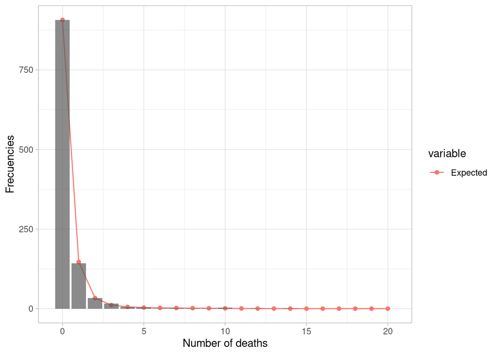

```r
data <- data.frame(data, x =  0:20)
data1 <- data[1:21, ]
data2 <- data[22:42, ]
pl1 <- ggplot() +
  geom_line(data1, mapping = aes(x = x, y = value, group = variable
                          , color = variable)) +
  geom_point(data1, mapping = aes(x = x, y = value, group = variable,
                           color = variable)) +
  geom_col(data2, mapping = aes(x = x, y = value, group = variable),
           alpha = 0.7) +
  theme_light() +
  labs(x = "Number of deaths",
       y = "Frecuencies")
pl1
```